# Time Series Analysis on Traffic Accident Record in NYC

## Introduction

Every year, several people are injured on the streets due to various reasons such as speeding, alcohol, and distracted driving [1]. To reduce the number of people injured and killed on the streets, both short-term and long-term solutions, especially addressing the root causes, are needed. Understanding the root cause by analyzing historical data and detecting patterns and insights is crucial for developing a well-structured plan.

In this study, we will investigate motor vehicle collision data to determine whether the number of people injured exhibits seasonal variation and is thus predictable by the SARIMA model. This could help in planning and implementing more effective safety measures.

## Data Exploration

We use motor vehicle collision data from New York City from NYC OpenData [2]. We processed this data to finalize the monthly total number of people injured by vehicles from 2013 to 2023.

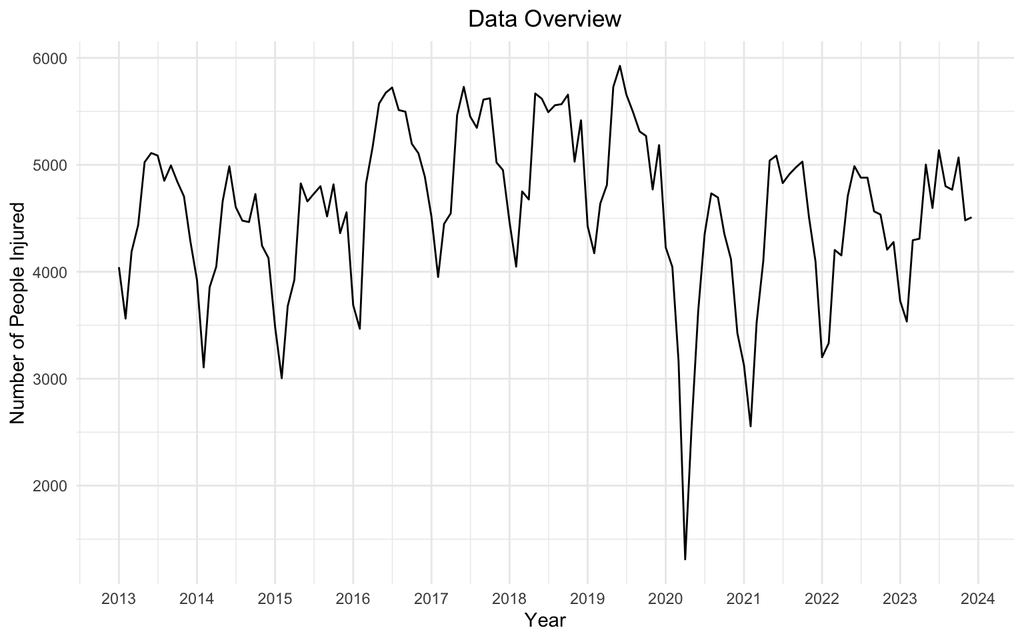

```r
Collision_data <- read.csv("Motor_Vehicle_Collisions_-_Crashes_20240220.csv")
Collision_data$date <- as.Date(Collision_data$date, format="%m/%d/%Y")
Collision_data <- Collision_data %>% filter(date >= as.Date("2013-01-01")) %>% filter(date < as.Date("2024-01-01"))

monthly_data <- Collision_data %>%
  group_by(year = year(date), month = month(date)) %>%
  summarise(person_injured = sum(person_injured)) %>%
  ungroup() %>%
  mutate(date = as.Date(paste(year, month, "01", sep = "-"))) %>%
  select(date, person_injured)

ggplot(monthly_data, aes(x = date, y = person_injured)) +
  geom_line() +
  labs(title = "Data Overview", x = "Year", y = "Number of People Injured") +
  theme_minimal() +
  scale_x_date(date_breaks = "1 year", date_labels = "%Y") +
  theme(plot.title = element_text(hjust = 0.5))
```

From the figure above, we can see that there is likely a seasonal trend in the number of people injured. We attempt to differentiate between the seasonal and trend components using the decompose function [3]. Identifying these components can help in understanding the underlying factors contributing to the injuries.

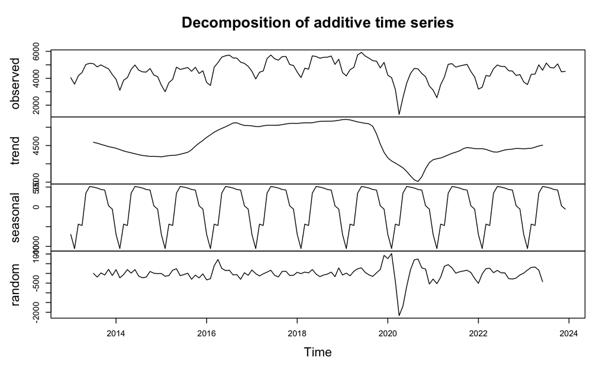

```r
person_injured_ts <- ts(monthly_data$person_injured, frequency = 12, start=c(2013, 1, 1))
person_injured_comp <- decompose(person_injured_ts)
plot(person_injured_comp)
```

The figure above shows the decomposition of the data into trend seasonal components. The trend was leveled during before and after covid time, while the biggest dip happened at the same time that Covid-19 hit the city [4]. If we look closer into the seasonal trend, we can the pattern has the period at exactly 1 year, where the highest peak and the lowest peak occur in June and February respectively. This behavior is correlated to the volume of pedestrian that directly affected by the weather within a year [5].

## Model Selection

In this section, we aim to find the appropriate model that fits the data on people injured.

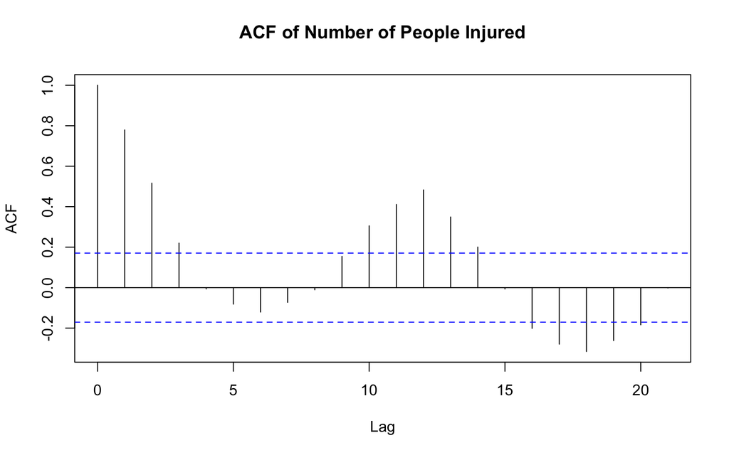

```r
acf(monthly_data$person_injured, main="ACF of Number of People Injured")
```

The ACF plot shows non-stationarity in the data, which is undesirable. We explore using the first-order difference to detrend the data and potentially obtain a stationary pattern:

$$z_n = \Delta y_n = y_n -
y_{n-1}$$

where $z_n$ is the first order difference of the data $y_n$

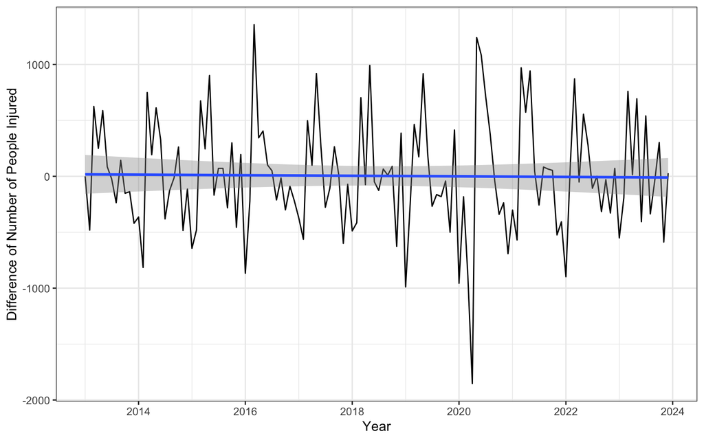

```r
ggplot(monthly_data, aes(x = date, y = c(0, diff(person_injured)))) +
  geom_line() +
  geom_smooth(method = 'lm',
              formula = y ~ x) +
  xlab("Year") +
  ylab("Difference of Number of People Injured") +
  theme_bw() +
  theme(plot.title = element_text(hjust = 0.5))
```

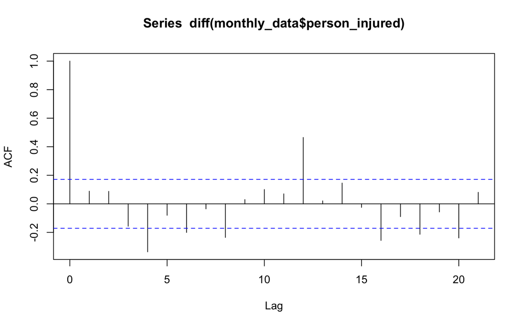

```r
acf(diff(monthly_data$person_injured))
```

The time series plot of the first-order difference shows fluctuations around zero value, indicative of stationarity. Also, the ACF plot suggests that a stationary model is suitable for describing the first difference of the data. At lag = 12, the first-order difference of the data shows a high value of autocorrelation, indicating a yearly seasonal component in the number of people injured.

```r
adf.test(diff(person_injured_ts))
```

```
##
##  Augmented Dickey-Fuller Test
##
## data:  diff(person_injured_ts)
## Dickey-Fuller = -6.7464, Lag order = 5, p-value = 0.01
## alternative hypothesis: stationary
```

By using ADF test, the result help verify that the first order difference of the number of people injured from vehicle is stationary. Therefore, we will select appropriate model from ARIMA with $d = 1$ from the following AIC table [6].

```r
create_aic_arima_table <- function(data,P,Q){
  table <- matrix(NA,(P+1),(Q+1))
  for(p in 0:P) {
    for(q in 0:Q) {
      table[p+1,q+1] <- arima(data,order=c(p,1,q))$aic
    }
  }
  dimnames(table) <- list(paste("AR",0:P, sep=""),
    paste("MA",0:Q,sep=""))
  table
}

aic_arima_table <- create_aic_arima_table(person_injured_ts,4,4)
kable(aic_arima_table,digits=2)
```

|  | MA0 | MA1 | MA2 | MA3 | MA4 |
| --- | --- | --- | --- | --- | --- |
| AR0 | 2004.77 | 2005.90 | 2003.77 | 2004.55 | 1978.43 |
| AR1 | 2005.74 | 2007.59 | 2005.55 | 1984.83 | 1979.61 |
| AR2 | 2006.89 | 2008.41 | 1999.76 | 1982.73 | 1980.56 |
| AR3 | 2004.76 | 1983.50 | 1976.02 | 1977.90 | 1982.26 |
| AR4 | 1991.67 | 1983.43 | 1980.34 | 1968.68 | 1984.07 |

$$H^{\langle0\rangle} : \theta \in
\Theta^{\langle0\rangle}$$
$$H^{\langle1\rangle} : \theta \in
\Theta^{\langle1\rangle}$$

where $\Theta^{\langle0\rangle}$ and $\Theta^{\langle1\rangle}$ are ARIMA$(3,1,2)$ and ARIMA$(4,1,3)$ parameter spaces respectively.

Then, we can use maximized log likelihood to test the hypothesis

$$2(l^{\langle1\rangle} -
l^{\langle0\rangle})
=2(sup_{\theta\in\Theta^{\langle1\rangle}}l(\theta)-sup_{\theta\in\Theta^{\langle0\rangle}}l(\theta)) \approx
\chi^2_{D^{\langle1\rangle}-D^{\langle0\rangle}}$$

where $\chi^2_d$ is a chi-squared random variable on $d$ degrees of freedom

```r
arima312_fit <- arima(person_injured_ts,order=c(3,1,2))
arima413_fit <- arima(person_injured_ts,order=c(4,1,3))

LR <- 2 * (arima413_fit$loglik - arima312_fit$loglik)

df <- length(coef(arima413_fit)) - length(coef(arima312_fit))

p_value <- pchisq(LR, df, lower.tail = FALSE)

cat("Likelihood Ratio Test Statistic:", LR, "\n",
    "Degrees of Freedom:", df, "\n",
    "P-value:", p_value)
```

```
## Likelihood Ratio Test Statistic: 11.33986
##  Degrees of Freedom: 2
##  P-value: 0.003448105
```

The result show P-value at $0.003$, meaning that there is a significant difference between ARIMA$(3,1,2)$ and ARIMA$(4,1,3)$. Therefore, we choose ARIMA$(4,1,3)$ for the preferred model to fit the people injured data.

```r
arima_fit <- arima(person_injured_ts, order = c(4, 1, 3))
summary(arima_fit)
```

```
##
## Call:
## arima(x = person_injured_ts, order = c(4, 1, 3))
##
## Coefficients:
##           ar1     ar2     ar3      ar4     ma1      ma2      ma3
##       -0.5881  0.5879  0.4412  -0.4070  0.7305  -0.7279  -0.9983
## s.e.   0.0801  0.0876  0.0880   0.0802  0.0919   0.0977   0.0662
##
## sigma^2 estimated as 161475:  log likelihood = -976.34,  aic = 1968.68
##
## Training set error measures:
##                    ME     RMSE      MAE       MPE     MAPE      MASE
## Training set 7.668448 400.3142 303.4297 -1.118871 7.775379 0.7894283
##                     ACF1
## Training set -0.04780007
```

Then, since previously we notice about seasonal pattern at lag = 12, we explore another appropriate model using SARIMA model. As we choose ARIMA$(4,1,3)$ in the previous step, we will scope the SARIMA model choices by exploring AIC value of only SARIMA$(4,1,3)(P,0,Q)_{12}$ where $P$ and $Q$ are SAR and SMA parameters respectively.

```r
create_aic_sarima_table <- function(data,P,Q){
  table <- matrix(NA,(P+1),(Q+1))
  for(p in 0:P) {
    for(q in 0:Q) {
      table[p+1,q+1] <- arima(data, order=c(4,1,3), seasonal=c(p,0,q))$aic
    }
  }
  dimnames(table) <- list(paste("AR",0:P, sep=""),
    paste("MA",0:Q,sep=""))
  table
}

aic_sarima_table <- create_aic_sarima_table(person_injured_ts,3,3)
kable(aic_sarima_table,digits=2)
```

|  | MA0 | MA1 | MA2 | MA3 |
| --- | --- | --- | --- | --- |
| AR0 | 1968.68 | 1960.54 | 1958.42 | 1956.96 |
| AR1 | 1961.96 | 1934.25 | 1935.83 | 1935.21 |
| AR2 | 1950.54 | 1935.82 | 1937.82 | 1939.62 |
| AR3 | 1946.15 | 1935.54 | 1937.31 | 1939.32 |

With the same pattern of inspecting AIC table from ARIMA model, we can choose the approriate SARIMA model with parameter P = 1 and Q = 1 since its has the lowest AIC value.

```r
sarima_fit <- arima(person_injured_ts, order=c(4,1,3), seasonal=c(1,0,1))
summary(sarima_fit)
```

```
##
## Call:
## arima(x = person_injured_ts, order = c(4, 1, 3), seasonal = c(1, 0, 1))
##
## Coefficients:
##           ar1     ar2      ar3      ar4     ma1      ma2      ma3    sar1
##       -0.4588  0.4865  -0.1859  -0.2910  0.4630  -0.6214  -0.1432  0.9993
## s.e.   0.3483  0.1659   0.2576   0.1022  0.3625   0.1650   0.3279  0.0034
##          sma1
##       -0.9596
## s.e.   0.0963
##
## sigma^2 estimated as 105186:  log likelihood = -957.13,  aic = 1934.25
##
## Training set error measures:
##                    ME     RMSE      MAE        MPE     MAPE      MASE
## Training set 5.069396 323.0939 219.3543 -0.8958813 5.866573 0.5706905
##                      ACF1
## Training set -0.008479578
```

```r
LR <- 2 * (sarima_fit$loglik - arima_fit$loglik)

df <- length(coef(sarima_fit)) - length(coef(arima_fit))

p_value <- pchisq(LR, df, lower.tail = FALSE)

cat("Likelihood Ratio Test Statistic:", LR, "\n",
    "Degrees of Freedom:", df, "\n",
    "P-value:", p_value)
```

```
## Likelihood Ratio Test Statistic: 38.42574
##  Degrees of Freedom: 2
##  P-value: 4.528533e-09
```

The result show P-value very close to zero, meaning that SARIMA model is statistically different from ARIMA model. Therefore, we finalize the model selection with SARIMA$(4,1,3)(1,0,1)_{12}$ model.